# 2018-01-10_simulate_perf_curves

Antdrew D. Nguyen, Evolutionary Physiologist

# Workflow

Simulate 3 possible outcomes for how performance curves (modeled as a gaussian function) can vary:

1. Veritical –traits are all correlated across environmental gradient
2. Horizontal – optimum varies along environmental gradient; so genotypes/clones have different optimum
3. Generalist-specialist – those with higher max performance, also operate over a smaller window along the environmental gradient

For each possibility:

```r
mermaid("
graph TD
  a{Simulate Data} --20 clones or colonies, 5 reps--> b(Mixed Effect Model)
  b --> c[Extract G]
  c --> d[PCA decomposition]
  d --> e[Visualize]
  a --> e
")
```

[interactive chart not shown]

# Constructing gaussian shaped performance curves

$$Performance = height * e^{(-0.5(\frac{Temperature - T_{opt}}{width})^2)}$$

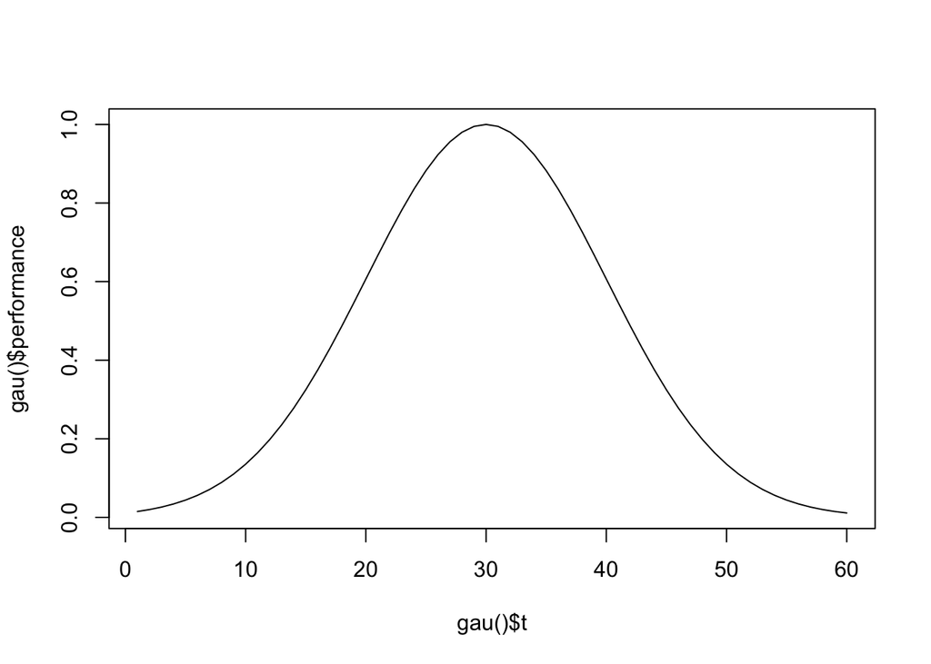

```r
gau<-function(a=1,b=30,c=10,t=seq(1,60,1)){
  #z=a*exp(-.5((t-b)/c)^2)
  z=a*exp(-.5*((t-b)/c)^2)
  b<-data.frame(performance=z,t=t)
  return(b)
}

#gau()
plot(gau()$t,gau()$performance,type="l")
```

## Simulate data with just vertical variation/responses

### making the data

```r
#simulate vert values
vval<-rnorm(mean=50,sd=15,n=100)
```

```r
#pull out 20, randomly

col<-sort(rep(sample(vval,20),5))


#estimate perf curves
random.error<-sample(rnorm(mean=0,sd=.5,n=1000),500)

#generate dataset with 5 reps for 20 colonies for 4 levels of temperature
dat<-rbind(gau(a=col,t=c(20,25,30,35,40)),gau(a=col,t=c(20,25,30,35,40)),gau(a=col,t=c(20,25,30,35,40)),gau(a=col,t=c(20,25,30,35,40)),gau(a=col,t=c(20,25,30,35,40)))
dat$performance<-dat$performance+random.error


#convert colonies and dat into factors
dat$colonies<-as.factor(rep(sort(rep(seq(1,20,1),5)),5))
dat$t<-as.factor(dat$t)
```

### Mixed effects model to estimate G

```r
### building mixed effects model to estimate the variance-covariance structure
# random slope and temperature nested within colonies
vmod<-lmer(formula=performance~1+(0+t|colonies),REML=TRUE,data=dat)
#summary(vmod)
Gmatrix.pac<-VarCorr(vmod)$colonies;Gmatrix.pac
```

```
##           t20      t25      t30      t35       t40
## t20  54.50538 102.3179 121.7970 101.8787  54.28518
## t25 102.31789 321.1719 412.7336 320.9144 101.88864
## t30 121.79701 412.7336 534.6840 412.5606 121.28229
## t35 101.87867 320.9144 412.5606 320.6630 101.45121
## t40  54.28518 101.8886 121.2823 101.4512  54.06680
## attr(,"stddev")
##       t20       t25       t30       t35       t40
##  7.382776 17.921271 23.123235 17.907065  7.353013
## attr(,"correlation")
##           t20       t25       t30       t35       t40
## t20 1.0000000 0.7733268 0.7134579 0.7706180 0.9999914
## t25 0.7733268 1.0000000 0.9959840 0.9999909 0.7731996
## t30 0.7134579 0.9959840 1.0000000 0.9963565 0.7133184
## t35 0.7706180 0.9999909 0.9963565 1.0000000 0.7704908
## t40 0.9999914 0.7731996 0.7133184 0.7704908 1.0000000
```

```r
Gmatrix.pac[1:5,1:5]
```

```
##           t20      t25      t30      t35       t40
## t20  54.50538 102.3179 121.7970 101.8787  54.28518
## t25 102.31789 321.1719 412.7336 320.9144 101.88864
## t30 121.79701 412.7336 534.6840 412.5606 121.28229
## t35 101.87867 320.9144 412.5606 320.6630 101.45121
## t40  54.28518 101.8886 121.2823 101.4512  54.06680
```

### PCA decomposition of G

```r
h<-princomp(Gmatrix.pac[1:5,1:5])
h$loadings[,1:3]
```

```
##         Comp.1      Comp.2       Comp.3
## t20 -0.1105533  0.68397392 -0.672405420
## t25 -0.5087036  0.03013044 -0.137851130
## t30 -0.6765092 -0.25954964  0.100792511
## t35 -0.5091354  0.01906278 -0.005883547
## t40 -0.1100687  0.68083950  0.720190441
```

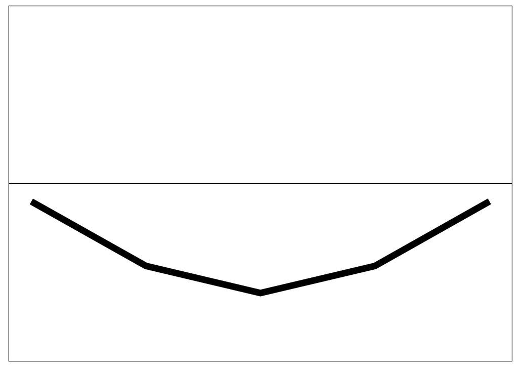

```r
h1<-data.frame(Loadings=h$loadings[,1],t=c(20,25,30,35,40))

aa<-ggplot(h1,aes(x=t,y=Loadings))+geom_line(size=3)+setup+geom_hline(yintercept=0)+ylim(-1,1)
aa
```

- y axis = loadings
- x axis = environmental gradient

### Figure

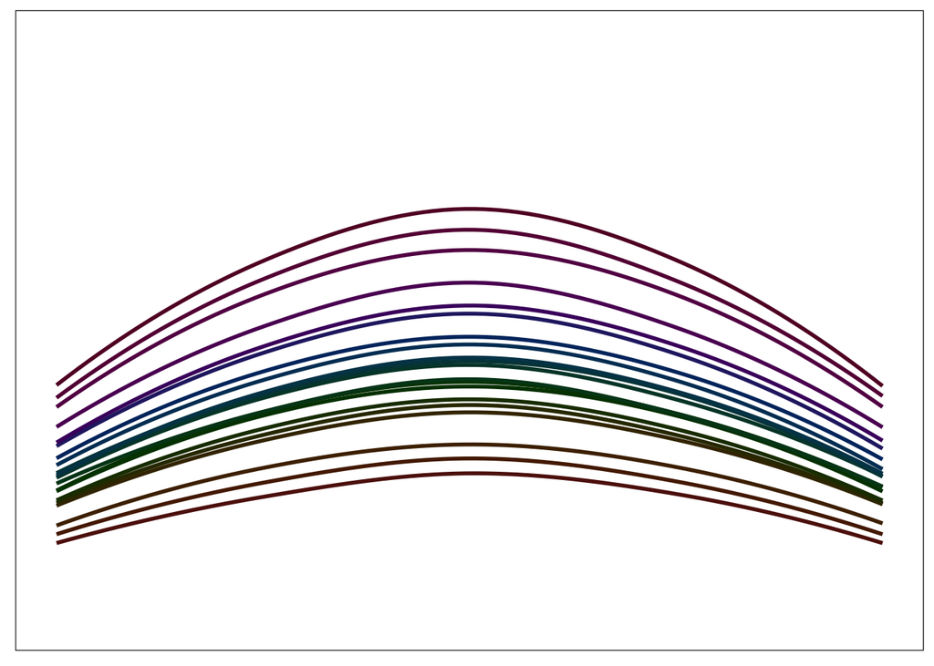

```r
dat$t<-as.numeric(as.character(dat$t))
a<-ggplot(dat,aes(x=t,y=performance,colour=factor(colonies)))+geom_smooth(se=FALSE)+setup+scale_color_hue(l=20, c=50)+ylim(5,100)
a
```

## Simulate horizontal variation

```r
#simulate Topt values
opt<-rnorm(mean=30,sd=5,n=100)

#pull out 20, randomly
col.opt<-sort(rep(sample(opt,20),5))
col.opt
```

```
##   [1] 17.46478 17.46478 17.46478 17.46478 17.46478 19.23733 19.23733
##   [8] 19.23733 19.23733 19.23733 22.62990 22.62990 22.62990 22.62990
##  [15] 22.62990 23.20901 23.20901 23.20901 23.20901 23.20901 23.52136
##  [22] 23.52136 23.52136 23.52136 23.52136 24.04828 24.04828 24.04828
##  [29] 24.04828 24.04828 26.42409 26.42409 26.42409 26.42409 26.42409
##  [36] 28.79592 28.79592 28.79592 28.79592 28.79592 28.93078 28.93078
##  [43] 28.93078 28.93078 28.93078 29.42742 29.42742 29.42742 29.42742
##  [50] 29.42742 29.96915 29.96915 29.96915 29.96915 29.96915 29.97545
##  [57] 29.97545 29.97545 29.97545 29.97545 31.06853 31.06853 31.06853
##  [64] 31.06853 31.06853 31.58897 31.58897 31.58897 31.58897 31.58897
##  [71] 34.90058 34.90058 34.90058 34.90058 34.90058 35.49250 35.49250
##  [78] 35.49250 35.49250 35.49250 35.63137 35.63137 35.63137 35.63137
##  [85] 35.63137 38.21021 38.21021 38.21021 38.21021 38.21021 38.24294
##  [92] 38.24294 38.24294 38.24294 38.24294 42.62495 42.62495 42.62495
##  [99] 42.62495 42.62495
```

```r
#estimate perf curves
#random.error<-sample(rnorm(mean=0,sd=.5,n=1000),500)

#generate dataset with 5 reps for 20 colonies for 4 levels of temperature
dat2<-rbind(gau(b=col.opt,t=c(20,25,30,35,40)),gau(b=col.opt,t=c(20,25,30,35,40)),gau(b=col.opt,t=c(20,25,30,35,40)),gau(b=col.opt,t=c(20,25,30,35,40)),gau(b=col.opt,t=c(20,25,30,35,40)))
dat2$performance<-dat2$performance#+random.error

###
dat2$colonies<-as.factor(rep(sort(rep(seq(1,20,1),5)),5))
dat2$t<-as.factor(dat2$t)
```

### Mixed effects model to Estimate G

```r
### building mixed effects model to estimate the variance-covariance structure
# random slope and temperature nested within colonies
hmod<-lmer(formula=performance~1+(0+t|colonies),REML=TRUE,data=dat2)
#summary(hmod)
Gmatrix.pac<-VarCorr(hmod)$colonies;Gmatrix.pac
```

```
##              t20          t25          t30          t35          t40
## t20  0.008462427  0.002629555 -0.002931756 -0.005748646 -0.003865895
## t25  0.002629555  0.006078570  0.006161661  0.002503909 -0.002538527
## t30 -0.002931756  0.006161661  0.011233070  0.009146578  0.001351397
## t35 -0.005748646  0.002503909  0.009146578  0.010188946  0.005368690
## t40 -0.003865895 -0.002538527  0.001351397  0.005368690  0.008590684
## attr(,"stddev")
##        t20        t25        t30        t35        t40
## 0.09199145 0.07796518 0.10598618 0.10094031 0.09268594
## attr(,"correlation")
##            t20        t25        t30        t35        t40
## t20  1.0000000  0.3666351 -0.3006984 -0.6190896 -0.4534075
## t25  0.3666351  1.0000000  0.7456720  0.3181656 -0.3512911
## t30 -0.3006984  0.7456720  1.0000000  0.8549579  0.1375688
## t35 -0.6190896  0.3181656  0.8549579  1.0000000  0.5738387
## t40 -0.4534075 -0.3512911  0.1375688  0.5738387  1.0000000
```

```r
Gmatrix.pac[1:5,1:5]
```

```
##              t20          t25          t30          t35          t40
## t20  0.008462427  0.002629555 -0.002931756 -0.005748646 -0.003865895
## t25  0.002629555  0.006078570  0.006161661  0.002503909 -0.002538527
## t30 -0.002931756  0.006161661  0.011233070  0.009146578  0.001351397
## t35 -0.005748646  0.002503909  0.009146578  0.010188946  0.005368690
## t40 -0.003865895 -0.002538527  0.001351397  0.005368690  0.008590684
```

### PCA decomposition of G

```r
h<-princomp(Gmatrix.pac[1:5,1:5])
h$loadings[,1:3]
```

```
##          Comp.1     Comp.2     Comp.3
## t20 -0.54281122 -0.1730634  0.4927257
## t25 -0.02010738 -0.5782824  0.4412969
## t30  0.44441426 -0.5551914  0.1438323
## t35  0.60466693 -0.1155643 -0.1026693
## t40  0.37659732  0.5603980  0.7288688
```

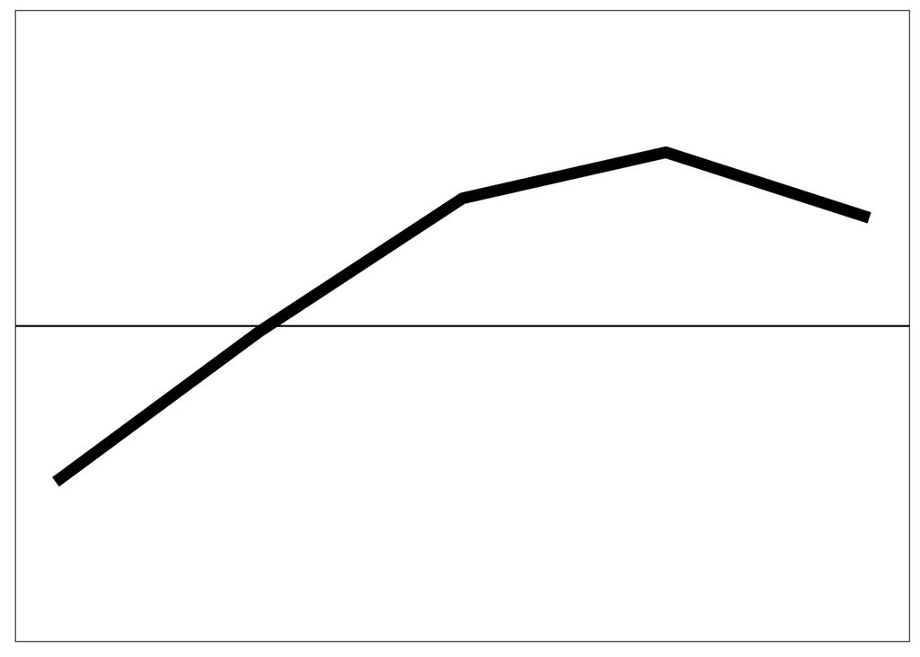

```r
h2<-data.frame(Loadings=h$loadings[,1],t=c(20,25,30,35,40))

bb<-ggplot(h2,aes(x=t,y=Loadings))+geom_line(size=3)+setup+geom_hline(yintercept=0)+ylim(-1,1)
bb
```

- y axis = loadings
- x axis = environmental gradient

### Figure

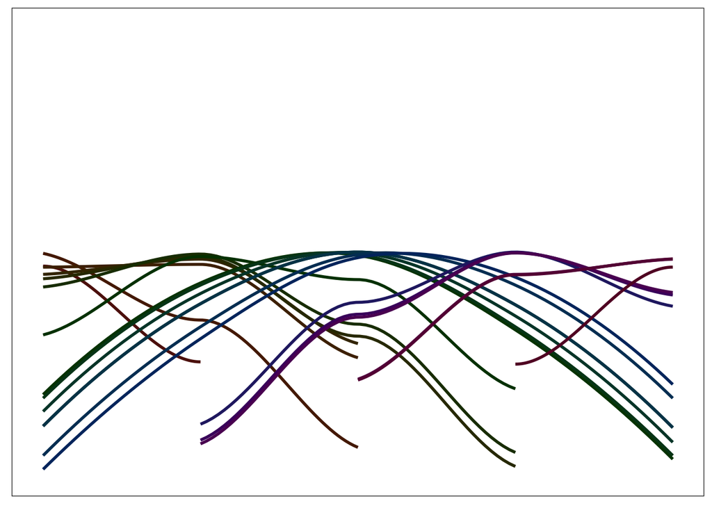

```r
dat2$t<-as.numeric(as.character(dat2$t))
b<-ggplot(dat2,aes(x=t,y=performance,colour=factor(colonies)))+stat_smooth(se=FALSE)+setup+scale_color_hue(l=20, c=50)+xlim(20,40)+ylim(0.5,1.5)
b
```

## Simulate generalist-specialist variation

### making the data

ones that have small widths, have higher performance

```r
col# height
```

```
##   [1] 29.17893 29.17893 29.17893 29.17893 29.17893 31.56051 31.56051
##   [8] 31.56051 31.56051 31.56051 34.10290 34.10290 34.10290 34.10290
##  [15] 34.10290 39.23620 39.23620 39.23620 39.23620 39.23620 40.17772
##  [22] 40.17772 40.17772 40.17772 40.17772 41.13169 41.13169 41.13169
##  [29] 41.13169 41.13169 43.67019 43.67019 43.67019 43.67019 43.67019
##  [36] 44.12453 44.12453 44.12453 44.12453 44.12453 44.50062 44.50062
##  [43] 44.50062 44.50062 44.50062 46.88992 46.88992 46.88992 46.88992
##  [50] 46.88992 47.67092 47.67092 47.67092 47.67092 47.67092 47.93938
##  [57] 47.93938 47.93938 47.93938 47.93938 49.81900 49.81900 49.81900
##  [64] 49.81900 49.81900 51.71191 51.71191 51.71191 51.71191 51.71191
##  [71] 55.28158 55.28158 55.28158 55.28158 55.28158 56.60274 56.60274
##  [78] 56.60274 56.60274 56.60274 60.34644 60.34644 60.34644 60.34644
##  [85] 60.34644 65.85102 65.85102 65.85102 65.85102 65.85102 68.76625
##  [92] 68.76625 68.76625 68.76625 68.76625 72.25288 72.25288 72.25288
##  [99] 72.25288 72.25288
```

```r
w<-rnorm(mean=5,sd=3,n=100)
col.opt<-sort(rep(sample(w,20),5))
col.opt # width
```

```
##   [1] -1.04030670 -1.04030670 -1.04030670 -1.04030670 -1.04030670
##   [6] -0.07626436 -0.07626436 -0.07626436 -0.07626436 -0.07626436
##  [11]  0.04590489  0.04590489  0.04590489  0.04590489  0.04590489
##  [16]  0.06675090  0.06675090  0.06675090  0.06675090  0.06675090
##  [21]  0.11635840  0.11635840  0.11635840  0.11635840  0.11635840
##  [26]  0.98391728  0.98391728  0.98391728  0.98391728  0.98391728
##  [31]  2.50166695  2.50166695  2.50166695  2.50166695  2.50166695
##  [36]  3.36602219  3.36602219  3.36602219  3.36602219  3.36602219
##  [41]  4.34148408  4.34148408  4.34148408  4.34148408  4.34148408
##  [46]  5.37049735  5.37049735  5.37049735  5.37049735  5.37049735
##  [51]  5.69526301  5.69526301  5.69526301  5.69526301  5.69526301
##  [56]  5.73975361  5.73975361  5.73975361  5.73975361  5.73975361
##  [61]  6.04416952  6.04416952  6.04416952  6.04416952  6.04416952
##  [66]  6.21015014  6.21015014  6.21015014  6.21015014  6.21015014
##  [71]  6.42488734  6.42488734  6.42488734  6.42488734  6.42488734
##  [76]  6.53859724  6.53859724  6.53859724  6.53859724  6.53859724
##  [81]  7.48783142  7.48783142  7.48783142  7.48783142  7.48783142
##  [86]  8.35961041  8.35961041  8.35961041  8.35961041  8.35961041
##  [91]  8.98608002  8.98608002  8.98608002  8.98608002  8.98608002
##  [96]  9.49215644  9.49215644  9.49215644  9.49215644  9.49215644
```

```r
dat3<-rbind(gau(a=col,c=rev(col.opt),t=c(20,25,30,35,40)),gau(a=col,c=rev(col.opt),t=c(20,25,30,35,40)),gau(a=col,c=rev(col.opt),t=c(20,25,30,35,40)),gau(a=col,c=rev(col.opt),t=c(20,25,30,35,40)),gau(a=col,c=rev(col.opt),t=c(20,25,30,35,40)))
#dat3
dat3$colonies<-as.factor(rep(sort(rep(seq(1,20,1),5)),5))
dat3$t<-as.factor(dat2$t)
```

### Mixed effects model to estimate G

```r
###model
hwmod<-lmer(formula=performance~1+(0+t|colonies),REML=TRUE,data=dat3)
#summary(hmod)
Gmatrix.pac<-VarCorr(hwmod)$colonies;Gmatrix.pac
```

```
##            t20       t25        t30       t35        t40
## t20  16.893543  6.710576 -26.419762  6.709414  16.879612
## t25   6.710576 22.149189  -6.528732 22.138961   6.702128
## t30 -26.419762 -6.528732  59.782160 -6.525740 -26.444170
## t35   6.709414 22.138961  -6.525740 22.128738   6.700961
## t40  16.879612  6.702128 -26.444170  6.700961  16.866104
## attr(,"stddev")
##      t20      t25      t30      t35      t40
## 4.110176 4.706292 7.731892 4.704119 4.106836
## attr(,"correlation")
##            t20        t25        t30        t35        t40
## t20  1.0000000  0.3469130 -0.8313477  0.3470131  0.9999878
## t25  0.3469130  1.0000000 -0.1794172  1.0000000  0.3467580
## t30 -0.8313477 -0.1794172  1.0000000 -0.1794178 -0.8327924
## t35  0.3470131  1.0000000 -0.1794178  1.0000000  0.3468577
## t40  0.9999878  0.3467580 -0.8327924  0.3468577  1.0000000
```

```r
Gmatrix.pac[1:5,1:5]
```

```
##            t20       t25        t30       t35        t40
## t20  16.893543  6.710576 -26.419762  6.709414  16.879612
## t25   6.710576 22.149189  -6.528732 22.138961   6.702128
## t30 -26.419762 -6.528732  59.782160 -6.525740 -26.444170
## t35   6.709414 22.138961  -6.525740 22.128738   6.700961
## t40  16.879612  6.702128 -26.444170  6.700961  16.866104
```

### PCA decomposition of G

```r
h<-princomp(Gmatrix.pac[1:5,1:5])
h$loadings[,1:3]
```

```
##         Comp.1     Comp.2      Comp.3
## t20 -0.3973275  0.1024419 0.582941390
## t25 -0.1689273 -0.6868078 0.005256927
## t30  0.7919069 -0.1902054 0.580233497
## t35 -0.1688635 -0.6864290 0.005605736
## t40 -0.3974455  0.1021659 0.568726090
```

```r
summary(h)
```

```
## Importance of components:
##                           Comp.1      Comp.2       Comp.3       Comp.4
## Standard deviation     40.016963 12.37339941 9.505467e-03 5.658858e-07
## Proportion of Variance  0.912736  0.08726397 5.149960e-08 1.825217e-16
## Cumulative Proportion   0.912736  0.99999995 1.000000e+00 1.000000e+00
##                        Comp.5
## Standard deviation          0
## Proportion of Variance      0
## Cumulative Proportion       1
```

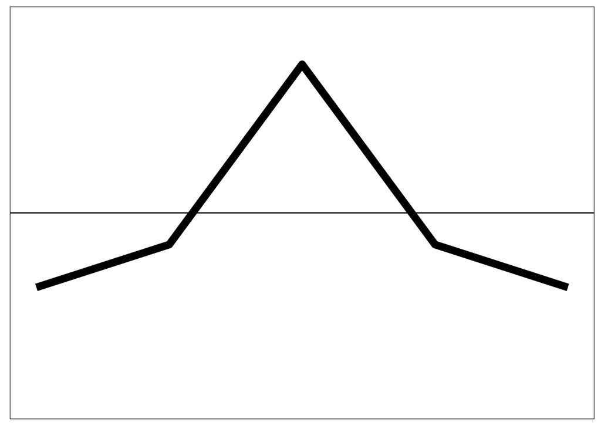

```r
#plot(h$loadings[,1])
h3<-data.frame(Loadings=h$loadings[,1],t=c(20,25,30,35,40))

cc<-ggplot(h3,aes(x=t,y=Loadings))+geom_line(size=3)+setup+geom_hline(yintercept=0)+ylim(-1,1)
cc
```

- y axis = loadings
- x axis = environmental gradient

### Figure

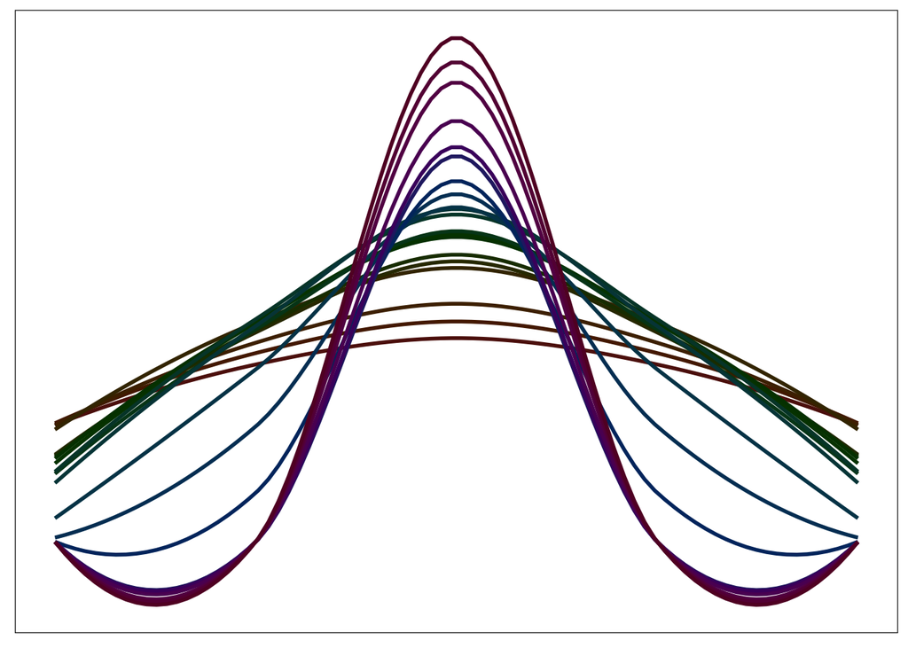

```r
dat3$t<-as.numeric(as.character(dat3$t))
c<-ggplot(dat3,aes(x=t,y=performance,colour=factor(colonies)))+stat_smooth(se=FALSE)+setup+scale_color_hue(l=20, c=50)
c
```

# Summary, all figs together

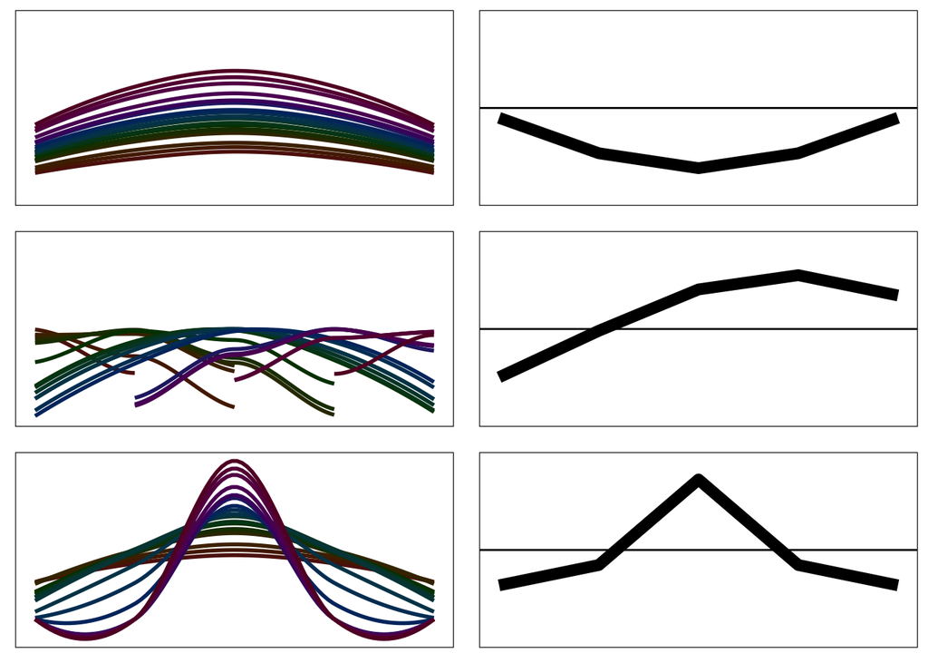

```r
grid.arrange(ncol=2,nrow=3,a,aa,b,bb,c,cc)
```

# References:

- **using mixed effects models, I followed [Paccard et al. 2016](http://www.journals.uchicago.edu/doi/abs/10.1086/685643):**

Paccard, A., Van Buskirk, J., & Willi, Y. (2016). Quantitative Genetic Architecture at Latitudinal Range Boundaries: Reduced Variation but Higher Trait Independence. The American Naturalist, 187(5), 667–77. https://doi.org/10.1086/685643

- **The idea of decomposing the population level variation (with known kinship) of performance curves , I followed [Joel Kingsolver’s work](http://jgking.web.unc.edu/publications/):**

Kingsolver, J.G., N. Heckman, J. Zhang, P.A. Carter, J.L. Knies, J.R. Stinchcombe, and K. Meyer. 2015. Genetic variation, simplicity, and evolutionary constraints for function-valued traits. The American Naturalist 185: E166-E181.

Stinchcombe, J. R., Function-valued Traits Working Group, M. Kirkpatrick. 2012. Genetics and evolution of function-valued traits: understanding environmentally responsive phenotypes. Trends in Ecology and Evolution.

Kingsolver, J. G., G. J. Ragland, and J. G. Shlichta. 2004. Quantitative genetics of continuous reaction norms: Thermal sensitivity of caterpillar growth rates. Evolution 58:1521-1529.